# Estudios de Informática, Multimedia y Telecomunicaciones

# Tipología y ciclo de vida de los datos: Práctica 2 Limpieza y validación de los datos

Autor: Marcos Azuaga Canteras

Diciembre 2018

```
## 'data.frame':    891 obs. of  12 variables:
##  $ PassengerId: int  1 2 3 4 5 6 7 8 9 10 ...
##  $ Survived   : int  0 1 1 1 0 0 0 0 1 1 ...
##  $ Pclass     : int  3 1 3 1 3 3 1 3 3 2 ...
##  $ Name       : chr  "Braund, Mr. Owen Harris" "Cumings, Mrs. John Bradley (Florence Briggs Thayer)" "Heikkinen, Miss. Laina" "Futrelle, Mrs. Jacques Heath (Lily May Peel)" ...
##  $ Sex        : chr  "male" "female" "female" "female" ...
##  $ Age        : num  22 38 26 35 35 NA 54 2 27 14 ...
##  $ SibSp      : int  1 1 0 1 0 0 0 3 0 1 ...
##  $ Parch      : int  0 0 0 0 0 0 0 1 2 0 ...
##  $ Ticket     : chr  "A/5 21171" "PC 17599" "STON/O2. 3101282" "113803" ...
##  $ Fare       : num  7.25 71.28 7.92 53.1 8.05 ...
##  $ Cabin      : chr  "" "C85" "" "C123" ...
##  $ Embarked   : chr  "S" "C" "S" "S" ...
```

Los registros del data set:

- survival: se identifica si el passajero sobrevive o no: 0 = No, 1 = Si
- pclass: Identifica la clase del passajero: 1 = 1a, 2 = 2a, 3 = 3a
- sex: Identifica el sexo del passajero male= Hombre , female=Mujer
- Age: Edad del pasajero.
- sibsp: Número de Hermanos o Esposo a bordo
- parch: Número de padres o hijos a bordo
- ticket: Identificador del billete
- fare: Importe pagado por el pasajero
- cabin: Número de la cabina
- embarked puerto de embarque C = Cherbourg, Q = Queenstown, S = Southampton

```
## PassengerId    Survived      Pclass        Name         Sex         Age
##           0           0           0           0           0         177
##      Ticket        Fare       Cabin    Embarked  Familiares
##           0           0           0           0           0
```

```
## PassengerId    Survived      Pclass        Name         Sex         Age
##           0           0           0           0           0           0
##      Ticket        Fare       Cabin    Embarked  Familiares
##           0           0         687           2           0
```

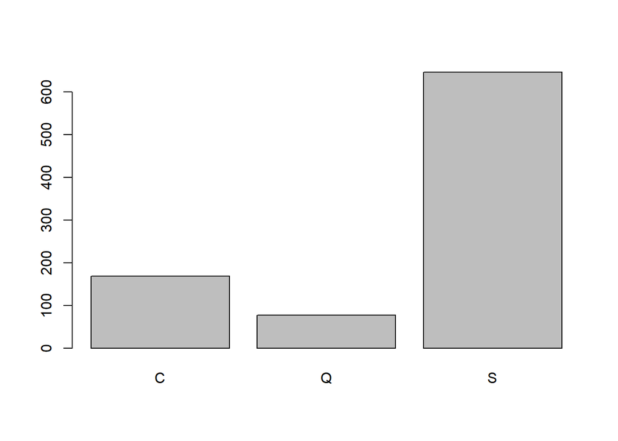

```
##   Survived     Pclass        Sex        Age       Fare   Embarked
##          0          0          0          0          0          0
## Familiares
##          0
```

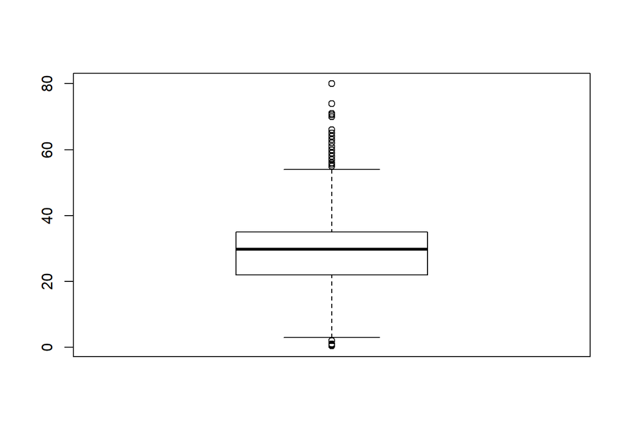

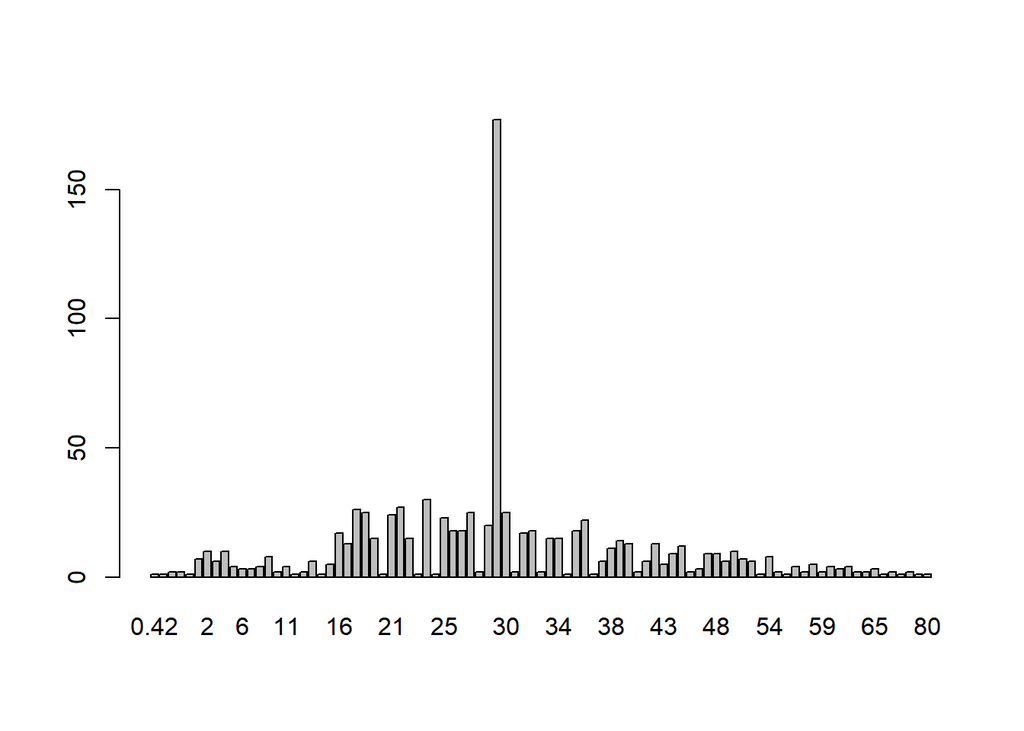

Aunque la variable Age se observan valores extremos , son legitimos.

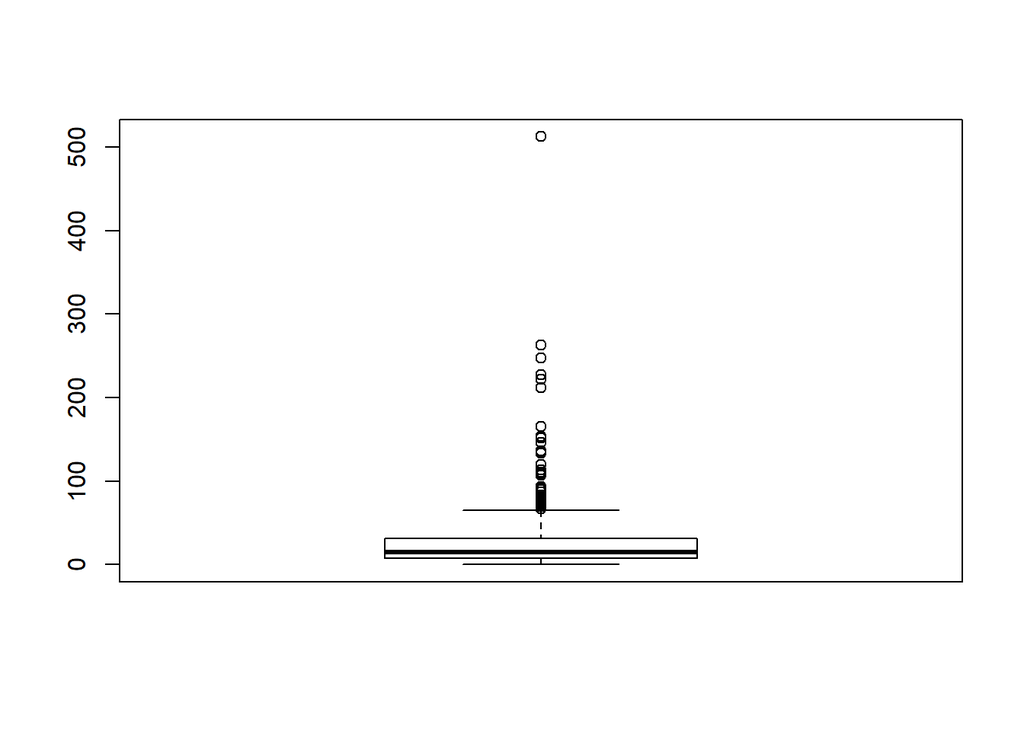

```r
#Buscamos valores extrmos de la variable Fare
boxplot(titanic$Fare)
```

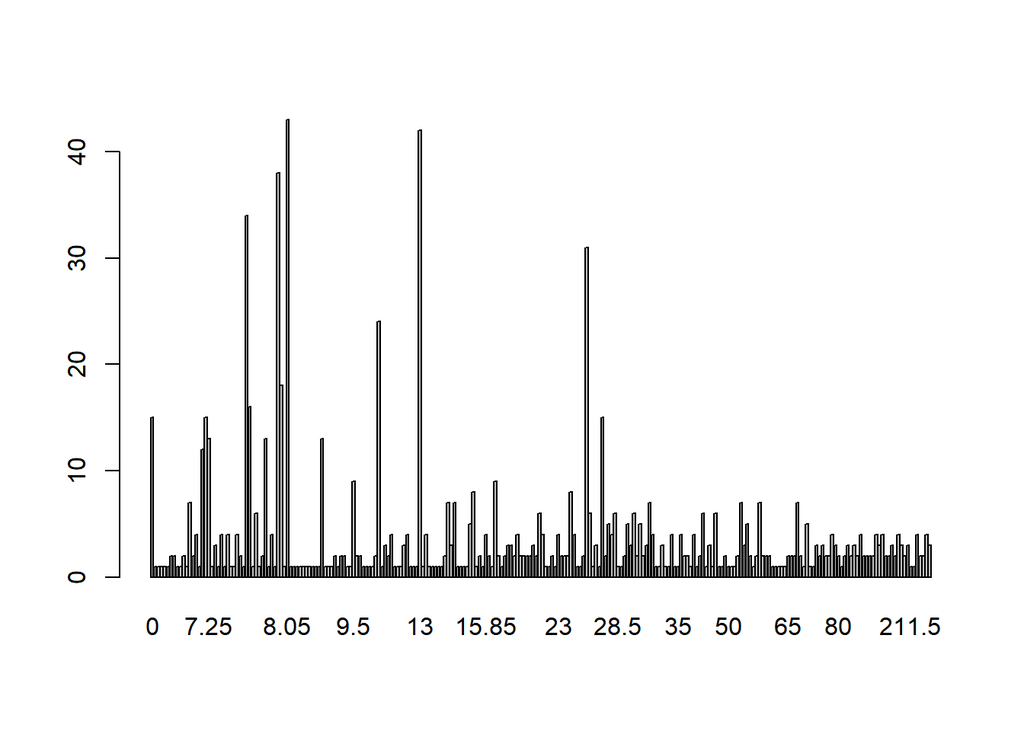

```r
barplot(table(titanic$Fare))
```

```r
max<-sort(unique(titanic$Fare), TRUE)[2]
titanic$Fare[titanic$Fare>max] <-max
m1<-mean(titanic$Fare[titanic$Pclass=="1a"])
m2<-mean(titanic$Fare[titanic$Pclass=="2a"])
m3<-mean(titanic$Fare[titanic$Pclass=="3a"])

titanic$Fare[titanic$Pclass==1 & titanic$Fare==0] <-m1
titanic$Fare[titanic$Pclass==2 & titanic$Fare==0] <-m2
titanic$Fare[titanic$Pclass==3 & titanic$Fare==0] <-m3
```

La variable Fare se observan valores extremos

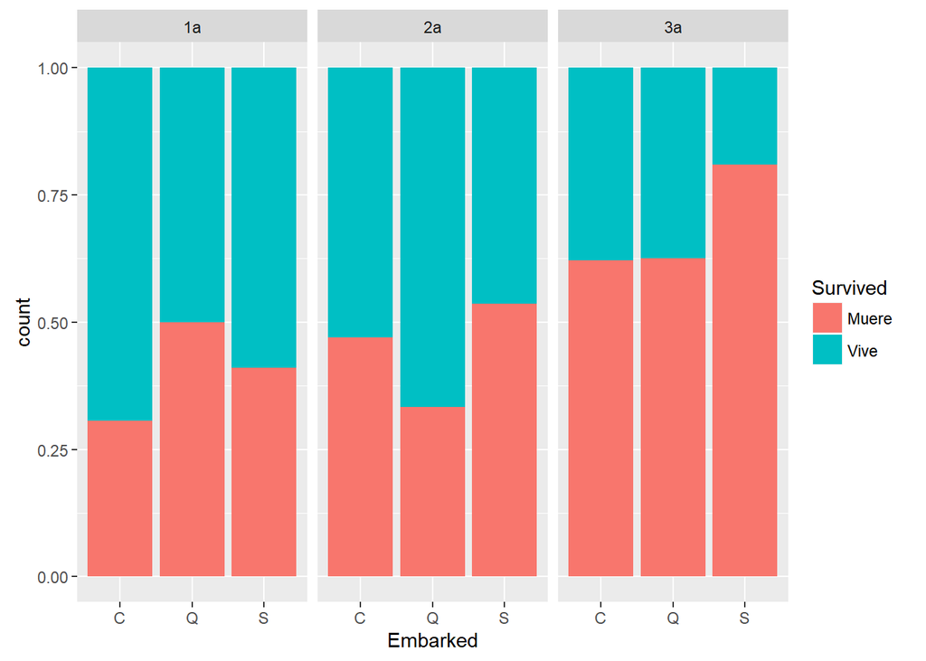

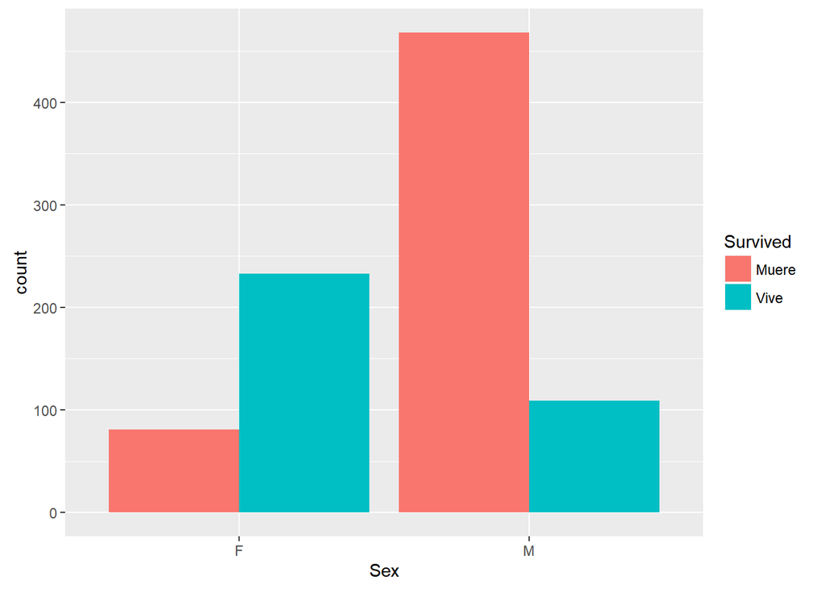

# 1 Pruebas estadisiticas

## 1.1 Prueba de hipotesis

Haremos una prueba estadistica para demostrar si influye el importe pagado por el billete con la posibilidad de sobrevivir o no, con un nivel de confianza del 95%

$$\left\{
\begin{array}{ll}
H_{0}: \mu_v=\mu_m\\
H_{1}: \mu_v>\mu_m
\end{array}
\right.$$

```r
TitanicMuere<-titanic[ which(titanic$Survived=="Muere"),]
TitanicVive<-titanic[ which(titanic$Survived=="Vive"),]
nc<-(1-0.95) #nivel de confianza
nM<-length(TitanicMuere$Fare) #número de registros
nV<-length(TitanicVive$Fare) #número de registros nNF
xM<-mean(TitanicMuere$Fare)#Media Fumador
xV<-mean(TitanicVive$Fare)#Media No Fumador xNF
resultadoM <- (TitanicMuere$Fare - xM)^2
vM<-sum(resultadoM)/(nM-1) #Varianza Fumador
resultadoV <- (TitanicVive$Fare - xV)^2
vV<-sum(resultadoV)/(nV-1)#Varianza No Fumador
z<-(xV-xM)/sqrt((vM/nM)+(vV/nV)) #Estadístico de contraste

sprintf("El valor estadístico de contraste es: %.4f",z)
```

```
## [1] "El valor estadístico de contraste es: 7.4713"
```

```r
vc<-qnorm(nc,mean=0,sd=1) #Valor crítico
sprintf("El valor crítico es: %.4f",vc)
```

```
## [1] "El valor crítico es: -1.6449"
```

```r
p<-pnorm(z,mean=0,sd=1,lower.tail = F)#p-Valor
sprintf("El p-valor es: %.4f",p)
```

```
## [1] "El p-valor es: 0.0000"
```

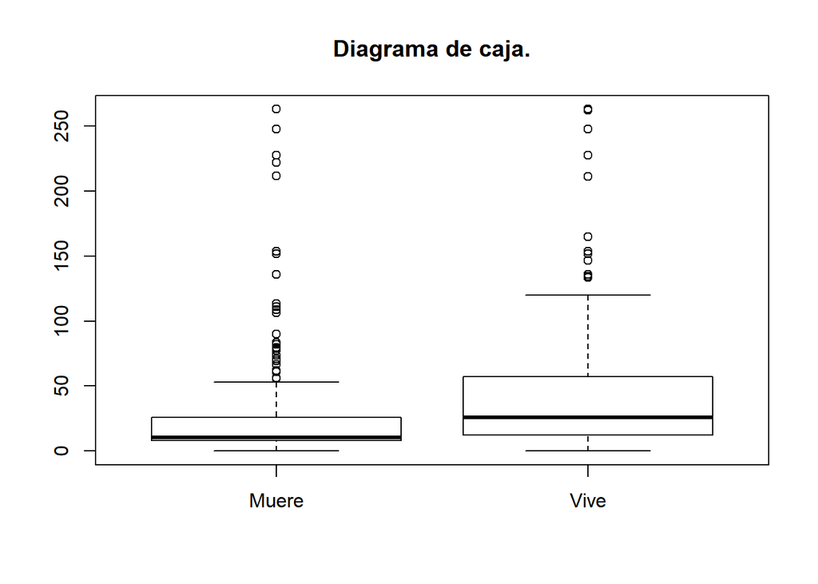

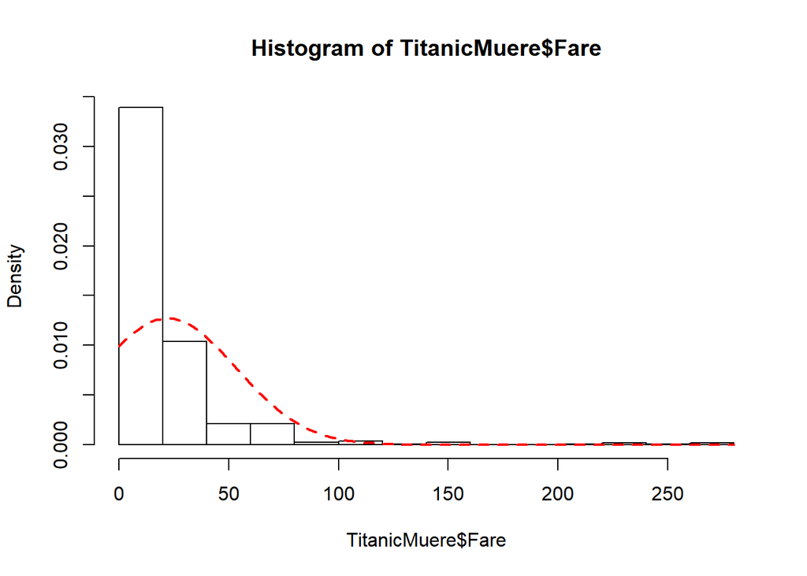

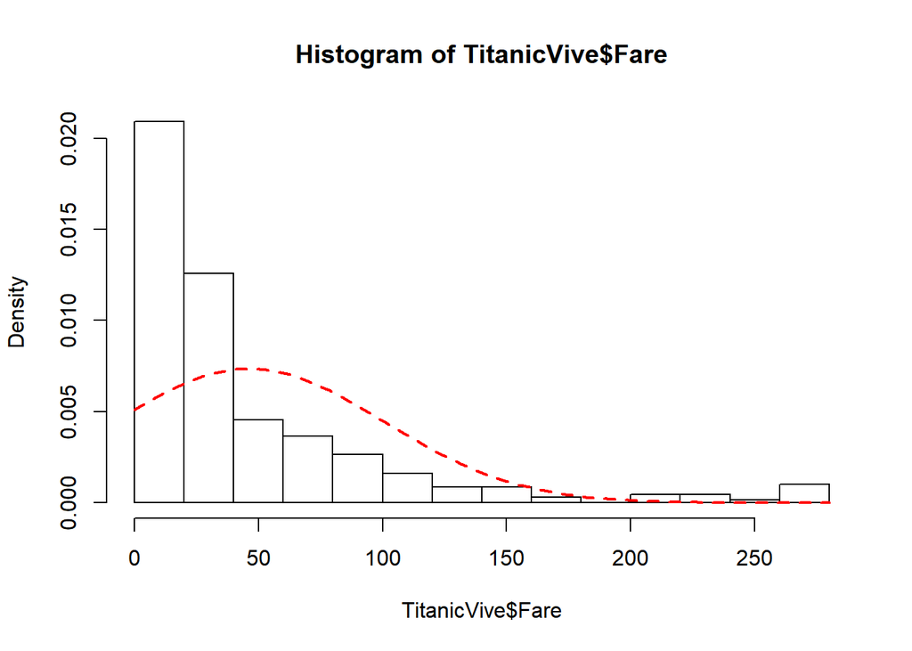

```
##
##  Welch Two Sample t-test
##
## data:  TitanicVive$Fare and TitanicMuere$Fare
## t = 7.4713, df = 484.98, p-value = 1.865e-13
## alternative hypothesis: true difference in means is greater than 0
## 95 percent confidence interval:
##  18.77658      Inf
## sample estimates:
## mean of x mean of y
##  46.20831  22.11789
```

Como el p-valor es 0.00 inferior a 0.05 , entonces rechazmos la hipotesis nula y aceptamos la hipotesis alternativa con lo que los supervivientes pagarón mas de media que los que murieron.

## 1.2 Regresión lineal

```
##
## Call:
## lm(formula = Survived ~ titanic$Sex + titanic$Pclass + titanic$Age +
##     titanic$Fare + titanic$Embarked + titanic$Familiares)
##
## Coefficients:
##        (Intercept)        titanic$SexM    titanic$Pclass2a
##          1.1778928          -0.5078654          -0.1514086
##   titanic$Pclass3a         titanic$Age        titanic$Fare
##         -0.3438131          -0.0057894           0.0002415
##  titanic$EmbarkedQ   titanic$EmbarkedS  titanic$Familiares
##         -0.0066423          -0.0710361          -0.0309439
```

```
## [1] 78.33895
```

```
## [1] 21.66105
```